# Financiamento de grandes setores econômicos na Campanha de parlamentares em exercício

Em 2018, quando foram eleitos 513 Deputados Federais e 54 Senadores, a eleição não permitiu a doação direta de empresas (pessoas jurídicas) para os candidatos, apenas doações de pessoas físicas. Iremos explorar nessa análise a participação dessas pessoas físicas como sócias de empresas e quais os setores de atividades econômicas que essas empresas pertencem.

Quando for falado em doações de setores econômicos para Parlamentares, deve ser intepretado como doações de sócios de empresas que atuam neste setor econômico. Setor econômico é o ramo de atividade que a empresa pode atuar. A classificação é obtida através da declaração dos CNAE’s das empresas na Receita Federal. Foi considerado o CNAE fiscal registrado na Receita Federal para determinatr o setor econômico de uma empresa.

Se um doador possuir duas ou mais empresas com diferentes setores econômicos então a doação será dividida pelo número de setores econômicos.

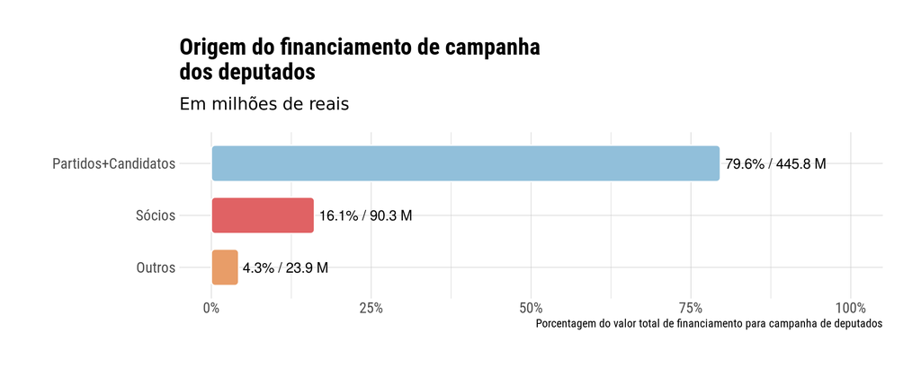

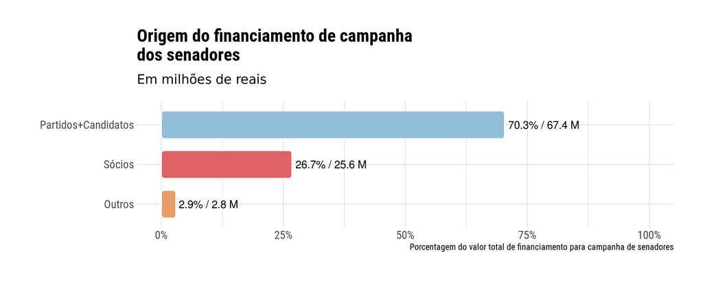

A seguir iremos visualizar quais os setores econômicos que mais doaram para deputados em 2018.

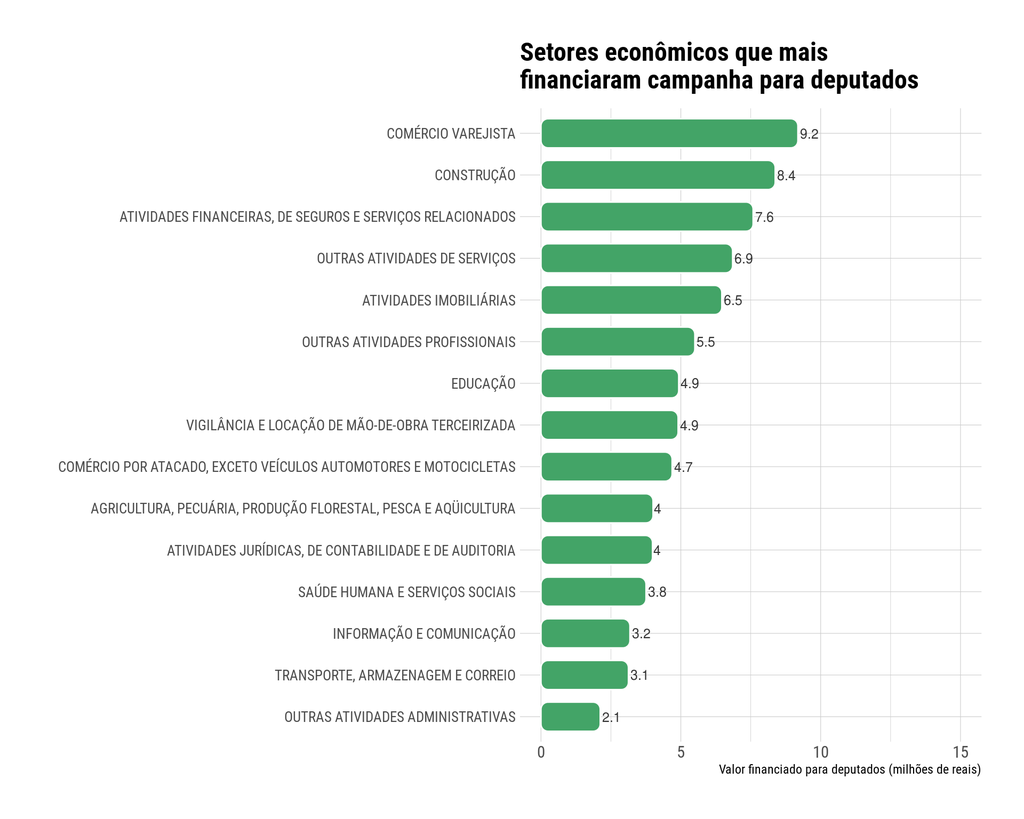

A seguir a lista dos setores que mais doaram para senadores

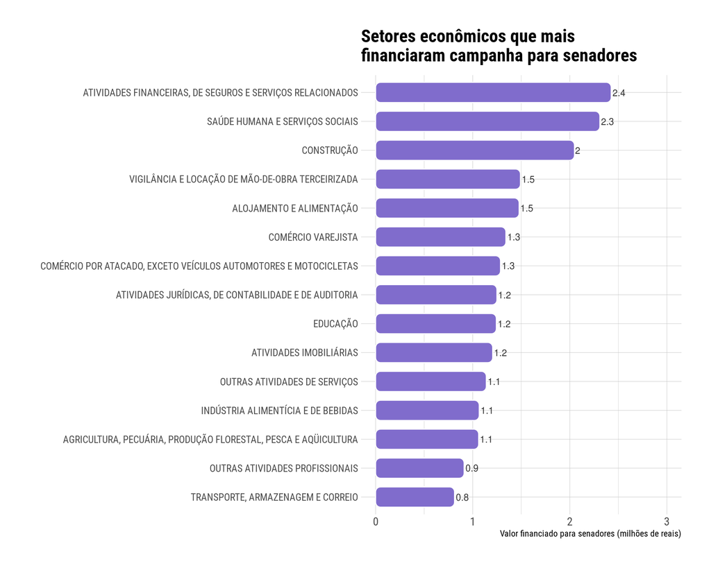

## Total doado por Setor Econômico

Abaixo exibimos a relação entre o valor total recebido em campanhas por setor econômico e o número de parlamentares que receberam essas doações. Todos os setores econômicos foram considerados nas visualizações.

### Para Deputados

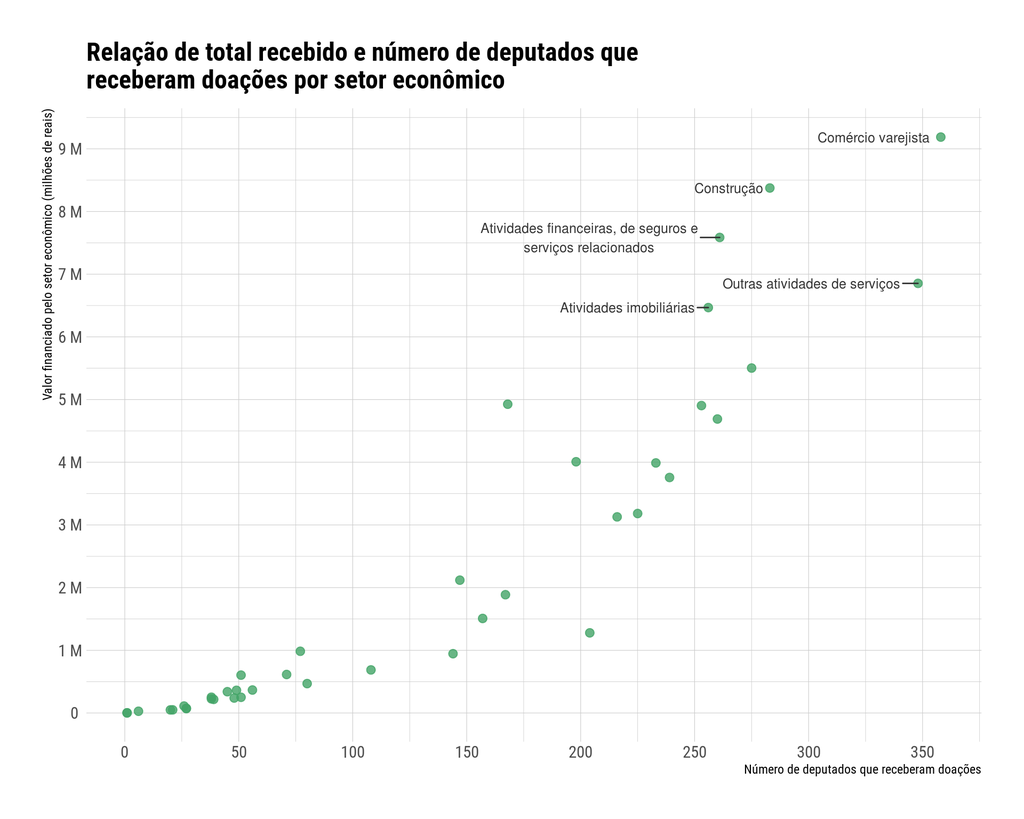

### Para Senadores

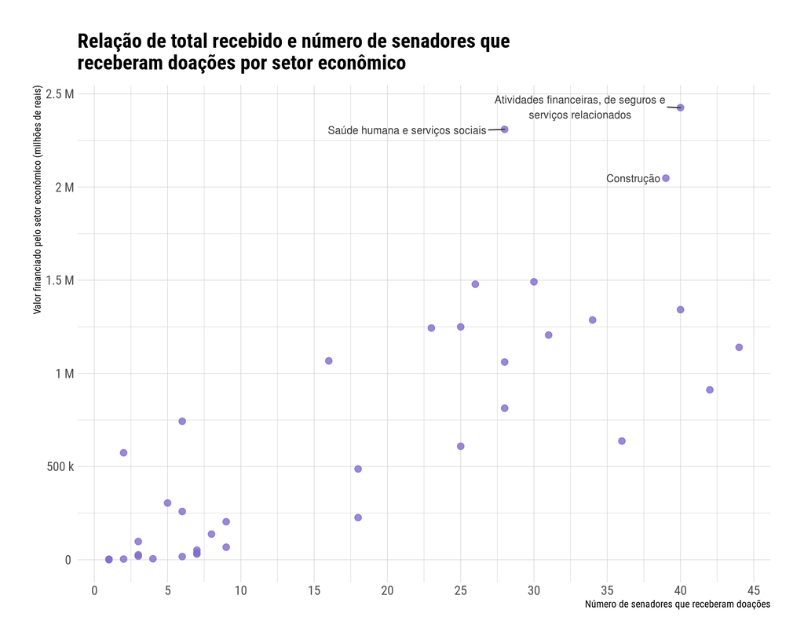

## Distribuição dos parlamentares por Setor Econômico

A seguir iremos visualizar a distribuição da proporção do recebido pelos parlamentares por Setor Econômico.

Cada aglomerado de pontos na visualização representa um conjunto de parlamentares posicionados de forma correspondente a proporção de doação recebida de um determinado setor econômico. A curva de densidade também ajuda a identificar concentração de parlamentares em faixas de valores específicas. A marca “|” preta na visualização representa a média da proporção dos parlamentares de cada setor. A visualização mostra os 10 setores econômicos com maiores médias de proporção da campanha de parlamentares.

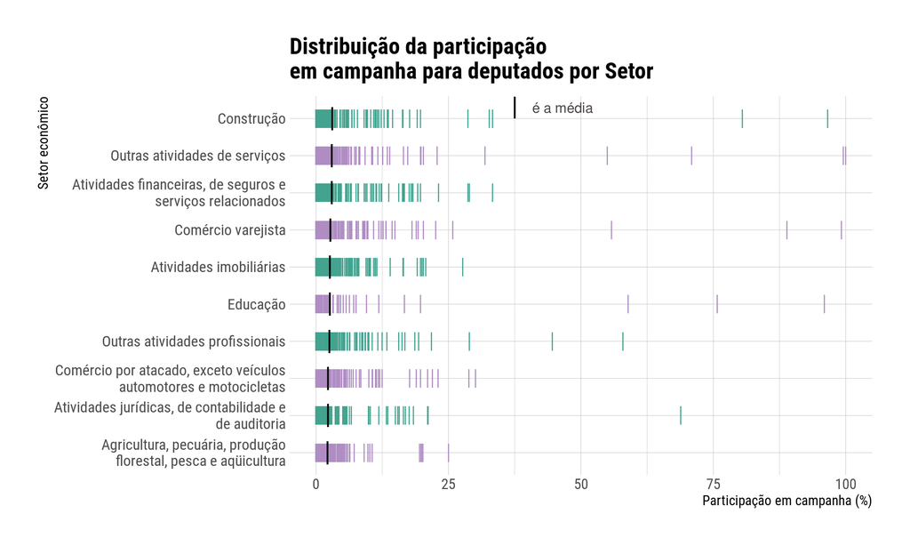

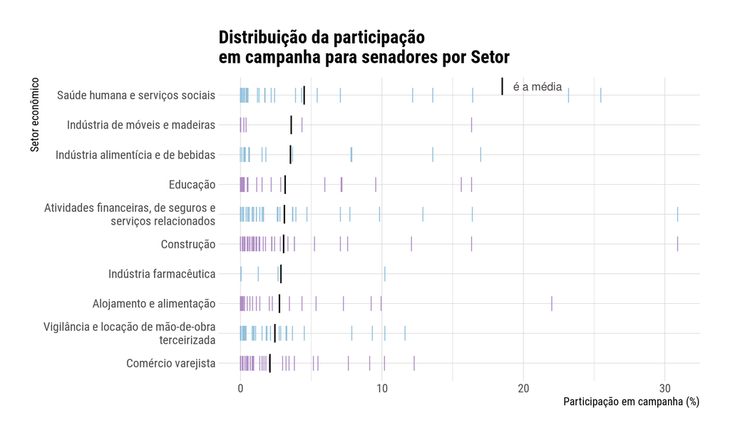

É possível perceber a ocorrência de vários casos de deputados com proporção de doação vinda do setor econômico superior a 50% na Câmara. Em alguns casos o valor se aproxima bastante de 100%, ou seja, toda a doação recebida pelo deputado veio de sócios ligados a empresas do setor econômico.

Para o Senado, o cenário é um pouco diferente: a maioria dos senadores não concentra nem 20% das doações recebidas em campanha em um setor específico.

## Distribuição dos parlamentares por Partido

Para o cálculo da participação em campanha, somamos, para cada partido, todas as receitas que vieram de sócios de empresas para os deputados desses partidos. Depois dividimos pela soma do valor total que cada deputado desse partido recebeu, isto é, considerando doações de pessoas físicas (sócias de empresas ou não) e doações do partido ou de outros candidatos. Ou seja, para cada partido temos a proporção de receitas provenientes de sócios.

A linha tracejada indica a média geral, que é o valor proporcional que um parlamentar recebeu de doações de sócios de empresas. Para a Câmara, um deputado recebe, em média, 20% de suas receitas de campanha são de doações de sócios de empresas. No Senado, este valor é de 25%.

A barra amarela representa a média geral de financiamento de campanha vindos de sócios de empresas. A barra azul representa a média de quanto os parlamentares de um partido tiveram suas campanhas financiadas por sócios de empresas.

Quando a barra amarela se sobressai significa que a média geral de financiamento de campanha vindos de sócios foi maior que a média do partido. Neste caso a barra cinza é a média do partido.

Caso a barra azul se sobressaia significa que a média do partido é maior que a média geral. Neste caso a barra cinza é a média geral.

## Para Deputados

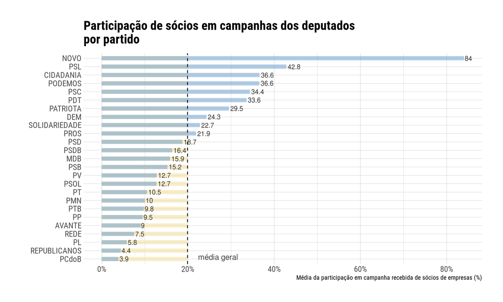

Proporcionalmente, NOVO e PSL foram os partidos que mais receberam doações de sócios de empresas quando comparados a média que um parlamentar recebe. Deputados do PSL, por exemplo, dentre todas suas receitas em campanha, mais de 42% vieram de sócios de empresas. A média geral considerando todos os deputados é próxima a 20%.

## Para Senadores

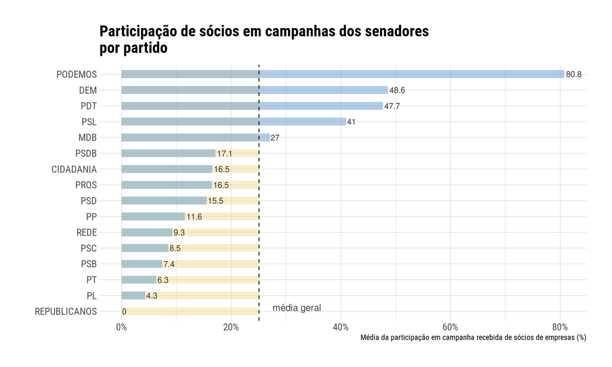

### Para Deputados

A seguir iremos visualizar a distribuição dos partidos que receberam, em média, mais doações de sócios de empresas proporcionalmente do que a média geral da Câmara. Para cada partido foi calculada a média de quanto cada setor econômico participou na campanha de seus deputados. Foram selecionados os seguintes setores econômicos:

- ATIVIDADES IMOBILIÁRIAS
- CONSTRUÇÃO
- ATIVIDADES FINANCEIRAS, DE SEGUROS E SERVIÇOS RELACIONADOS
- AGRICULTURA, PECUÁRIA, PRODUÇÃO FLORESTAL, PESCA E AQÜICULTURA
- COMÉRCIO VAREJISTA
- EDUCAÇÃO

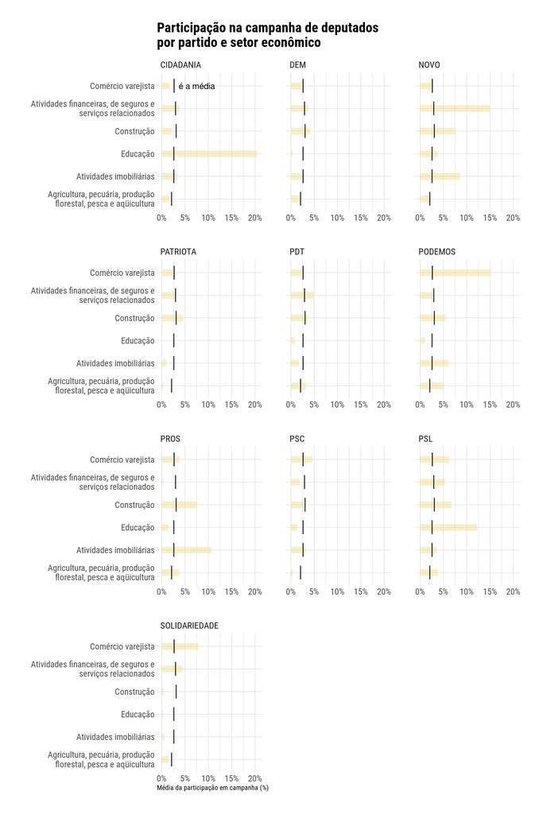

### Para Senadores

Para o Senado, foram selecionados os seguintes setores econômicos:

- SAÚDE HUMANA E SERVIÇOS SOCIAIS
- INDÚSTRIA DE MÓVEIS E MADEIRAS
- INDÚSTRIA ALIMENTÍCIA E DE BEBIDAS
- EDUCAÇÃO
- ATIVIDADES FINANCEIRAS, DE SEGUROS E SERVIÇOS RELACIONADOS
- CONSTRUÇÃO

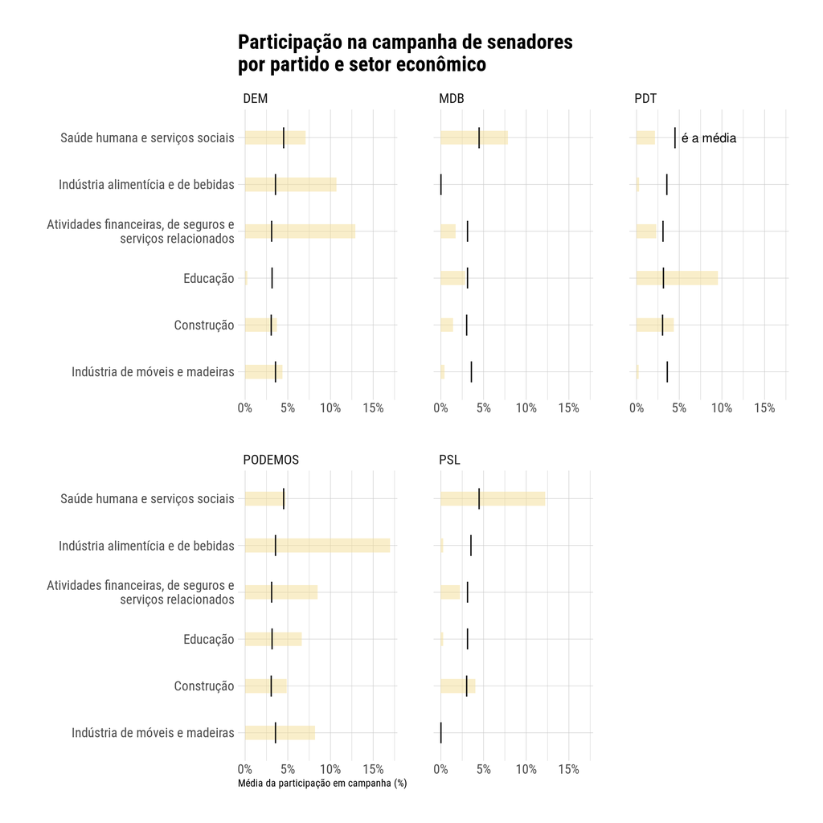

## Distribuição da média de participação em campanhas por comissão

A seguir visualizaremos a média de participação em campanhas dos principais setores econômicos por comissão permanente.

### Para deputados

- CCJC: Comissão De Constituição E Justiça E De Cidadania
- CMADS: Comissão De Meio Ambiente E Desenvolvimento Sustentável
- CFT: Comissão De Finanças E Tributação
- CDHM: Comissão De Direitos Humanos E Minorias
- CVT: Comissão De Viação E Transportes
- CMULHER: Comissão De Defesa Dos Direitos Da Mulher
- CINDRA: Comissão De Integração Nacional, Desenvolvimento Regional E Da Amazônia
- CE: Comissão de Educação
- CTASP: Comissão De Trabalho, De Administração E Serviço Público
- CME: Comissão De Minas E Energia

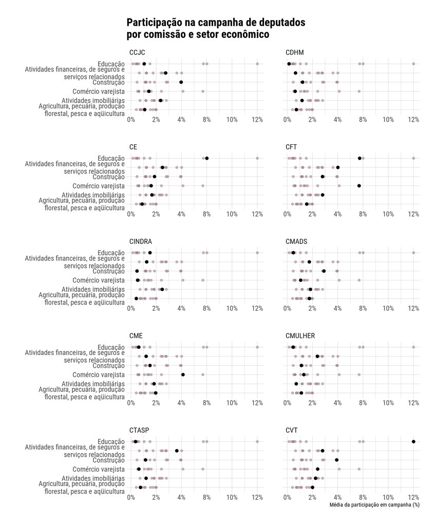

### Para Senadores

As Comissões permanentes escolhidas para o Senado para a análise:

- CCJ: Comissão De Constituição, Justiça E Cidadania
- CDH: Comissão De Direitos Humanos E Legislação Participativa
- CMA: Comissão De Meio Ambiente
- CRA: Comissão De Agricultura E Reforma Agrária
- CRE: Comissão De Relações Exteriores E Defesa Nacional
- CTFC: Comissão De Transparência, Governança, Fiscalização E Controle E Defesa Do Consumidor
- CI: Comissão De Serviços De Infraestrutura
- CE: Comissão De Educação, Cultura E Esporte

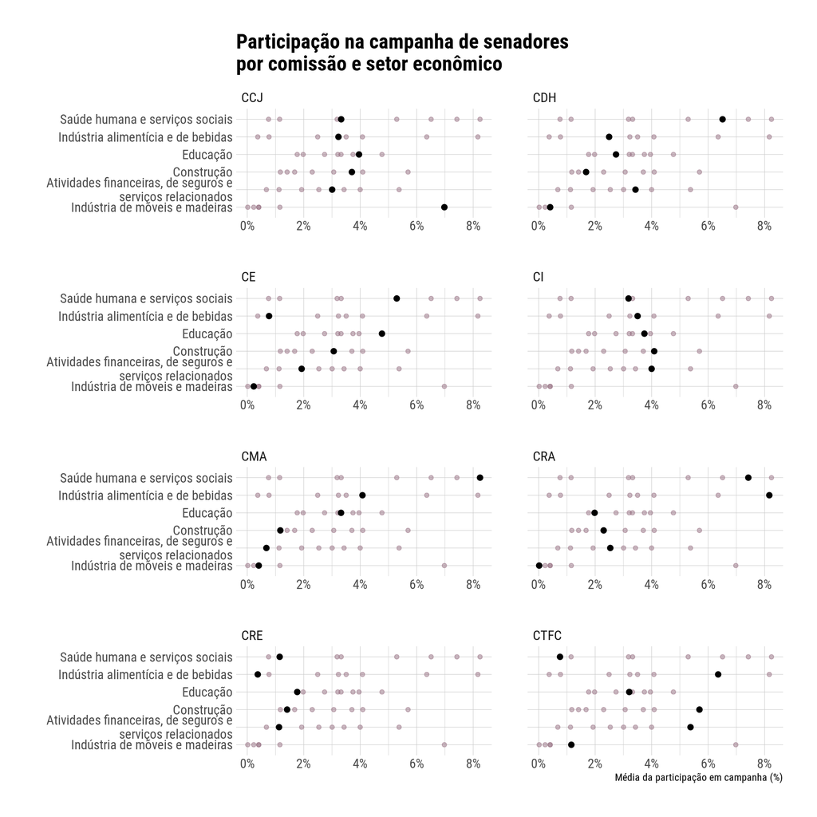